# Regression models, model fit, and prediction errors

Jamison Orton

2026-06-23

# 1 Task 1: Data and Regression Model

## 1.1 Question 1: Setup and starting code

### 1.1.1 Part A - Set up, data import and inspection code

```r
library(psych)
library(rpart)
library(RWeka)
library(caret)
library(rminer)
library(matrixStats)
library(knitr)
library(tidyverse)
mydir <- getwd()
setwd(mydir)

vgsales <- read.csv(file = "NA_sales_filtered.csv", stringsAsFactors = FALSE, fileEncoding = "latin1")

vgsales %>% str()
```

```
## 'data.frame':    6345 obs. of  9 variables:
##  $ Name        : chr  "Final Fantasy VII" "Final Fantasy X" "The Sims 3" "Final Fantasy VIII" ...
##  $ Platform    : chr  "PS" "PS2" "PC" "PS" ...
##  $ Genre       : chr  "Role-Playing" "Role-Playing" "Simulation" "Role-Playing" ...
##  $ Rating      : chr  "T" "T" "T" "T" ...
##  $ Critic_Score: int  92 92 86 90 96 88 92 96 93 87 ...
##  $ Critic_Count: int  20 53 75 24 15 29 97 105 57 22 ...
##  $ User_Score  : int  91 86 75 85 90 84 82 87 72 80 ...
##  $ User_Count  : int  1282 1056 886 644 367 135 3712 5187 2182 78 ...
##  $ NA_Sales    : num  3.01 2.91 0.99 2.28 3.27 2.93 2.77 3.27 0.08 3.11 ...
```

```r
vgsales <- vgsales %>%
  mutate(across(where(is.character) & !all_of("Name"), as.factor))

vgsales %>% summary()
```

```
##         Name         Platform             Genre          Rating
##  Length   :6345   PS2    :1135   Action      :1549   E      :1968
##  N.unique :4088   X360   : 848   Sports      : 921   E10+   : 877
##  N.blank  :   0   PS3    : 749   Shooter     : 798   M      :1295
##  Min.nchar:   2   XB     : 578   Role-Playing: 643   missing:  23
##  Max.nchar:  71   Wii    : 475   Racing      : 537   T      :2182
##                   DS     : 457   Platform    : 386
##                   (Other):2103   (Other)     :1511
##   Critic_Score    Critic_Count      User_Score      User_Count
##  Min.   :13.00   Min.   :  3.00   Min.   : 5.00   Min.   :    4.0
##  1st Qu.:61.00   1st Qu.: 14.00   1st Qu.:64.00   1st Qu.:   10.0
##  Median :72.00   Median : 25.00   Median :74.00   Median :   24.0
##  Mean   :69.82   Mean   : 28.97   Mean   :70.77   Mean   :  152.7
##  3rd Qu.:80.00   3rd Qu.: 40.00   3rd Qu.:81.00   3rd Qu.:   77.0
##  Max.   :98.00   Max.   :113.00   Max.   :95.00   Max.   :10665.0
##
##     NA_Sales
##  Min.   :0.0100
##  1st Qu.:0.0800
##  Median :0.1700
##  Mean   :0.3542
##  3rd Qu.:0.4100
##  Max.   :3.4900
##
```

### 1.1.2 Part B - Pairs panel distribution and correlation

```r
# Select only numeric variables
vgsales_numeric <- vgsales %>%
  select(where(is.numeric))

# Inspect the numeric variables included
str(vgsales_numeric)
```

```
## 'data.frame':    6345 obs. of  5 variables:
##  $ Critic_Score: int  92 92 86 90 96 88 92 96 93 87 ...
##  $ Critic_Count: int  20 53 75 24 15 29 97 105 57 22 ...
##  $ User_Score  : int  91 86 75 85 90 84 82 87 72 80 ...
##  $ User_Count  : int  1282 1056 886 644 367 135 3712 5187 2182 78 ...
##  $ NA_Sales    : num  3.01 2.91 0.99 2.28 3.27 2.93 2.77 3.27 0.08 3.11 ...
```

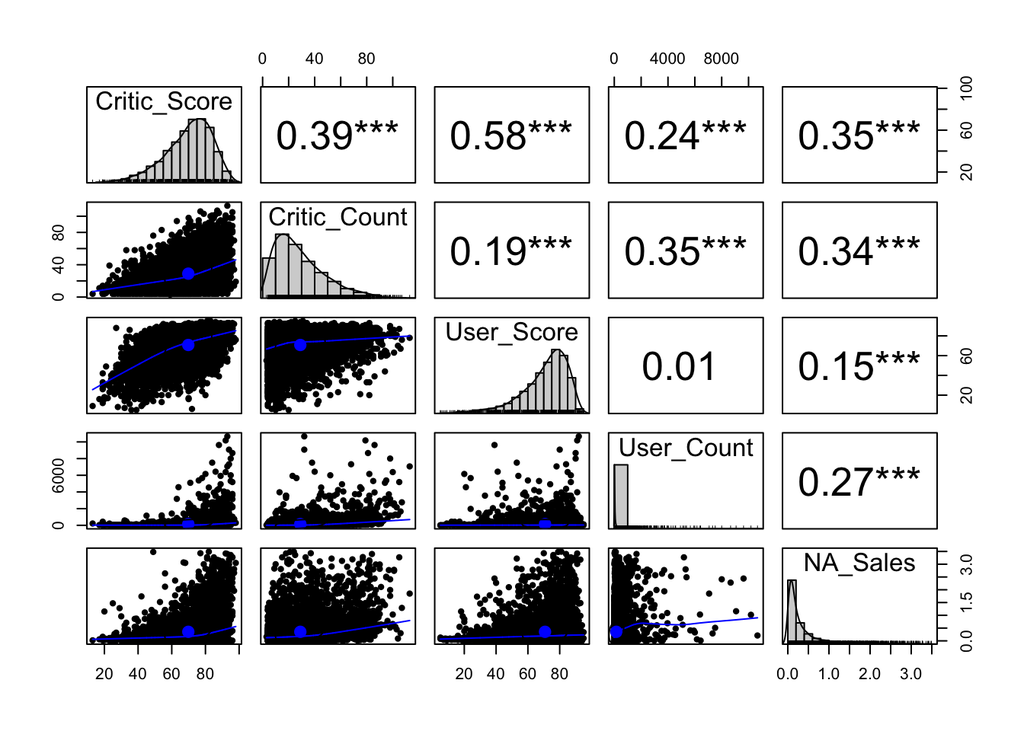

```r
# Show distributions and correlations
pairs.panels(
  vgsales_numeric,
  method = "pearson",
  hist.col = "lightgray",
  density = TRUE,
  ellipses = TRUE,
  stars = TRUE
)
```

### 1.1.3 Part C - Remove Name Variable, Regression model summary

```r
# Remove the Name variable from the data frame
vgsales_model <- vgsales %>%
  select(-Name)

vgsales_base <- vgsales_model

# Check that Name has been removed
str(vgsales_model)
```

```
## 'data.frame':    6345 obs. of  8 variables:
##  $ Platform    : Factor w/ 16 levels "3DS","DS","GBA",..: 6 7 5 6 6 7 8 8 5 6 ...
##  $ Genre       : Factor w/ 12 levels "Action","Adventure",..: 8 8 10 8 3 9 1 1 8 1 ...
##  $ Rating      : Factor w/ 5 levels "E","E10+","M",..: 5 5 5 5 5 5 5 5 5 5 ...
##  $ Critic_Score: int  92 92 86 90 96 88 92 96 93 87 ...
##  $ Critic_Count: int  20 53 75 24 15 29 97 105 57 22 ...
##  $ User_Score  : int  91 86 75 85 90 84 82 87 72 80 ...
##  $ User_Count  : int  1282 1056 886 644 367 135 3712 5187 2182 78 ...
##  $ NA_Sales    : num  3.01 2.91 0.99 2.28 3.27 2.93 2.77 3.27 0.08 3.11 ...
```

```r
# Build a linear regression model using NA_Sales as the target variable
lm_model <- lm(NA_Sales ~ ., data = vgsales_model)

# Show model summary: coefficients, significance, R-squared, adjusted R-squared, etc.
summary(lm_model)
```

```
##
## Call:
## lm(formula = NA_Sales ~ ., data = vgsales_model)
##
## Residuals:
##     Min      1Q  Median      3Q     Max
## -1.9381 -0.2315 -0.0818  0.0978  3.1769
##
## Coefficients:
##                     Estimate Std. Error t value Pr(>|t|)
## (Intercept)       -4.045e-01  4.796e-02  -8.435  < 2e-16 ***
## PlatformDS         1.547e-01  4.088e-02   3.783 0.000156 ***
## PlatformGBA        1.705e-01  4.573e-02   3.729 0.000194 ***
## PlatformGC         8.918e-02  4.276e-02   2.085 0.037071 *
## PlatformPC        -3.054e-01  4.554e-02  -6.706 2.17e-11 ***
## PlatformPS         4.075e-01  5.080e-02   8.020 1.25e-15 ***
## PlatformPS2        1.954e-01  3.851e-02   5.074 4.00e-07 ***
## PlatformPS3        9.718e-02  3.929e-02   2.473 0.013422 *
## PlatformPS4       -7.379e-02  4.670e-02  -1.580 0.114165
## PlatformPSP        4.007e-02  4.201e-02   0.954 0.340130
## PlatformPSV       -1.176e-01  5.741e-02  -2.049 0.040509 *
## PlatformWii        2.401e-01  4.070e-02   5.898 3.87e-09 ***
## PlatformWiiU       2.866e-02  5.892e-02   0.487 0.626616
## PlatformX360       1.387e-01  3.906e-02   3.551 0.000386 ***
## PlatformXB         2.122e-02  4.060e-02   0.523 0.601157
## PlatformXOne       1.621e-01  4.988e-02   3.251 0.001157 **
## GenreAdventure    -1.254e-01  3.082e-02  -4.068 4.81e-05 ***
## GenreFighting      3.030e-03  2.539e-02   0.119 0.905002
## GenreMisc          8.375e-02  2.503e-02   3.346 0.000823 ***
## GenrePlatform     -3.135e-02  2.551e-02  -1.229 0.219107
## GenrePuzzle       -1.315e-01  4.298e-02  -3.059 0.002230 **
## GenreRacing       -4.130e-02  2.282e-02  -1.810 0.070341 .
## GenreRole-Playing -1.030e-01  2.038e-02  -5.052 4.50e-07 ***
## GenreShooter       2.908e-03  1.894e-02   0.154 0.877966
## GenreSimulation    5.868e-02  2.951e-02   1.988 0.046825 *
## GenreSports       -2.387e-02  2.134e-02  -1.118 0.263445
## GenreStrategy     -1.726e-01  3.297e-02  -5.235 1.71e-07 ***
## RatingE10+        -5.782e-02  1.888e-02  -3.062 0.002205 **
## RatingM           -1.121e-01  2.107e-02  -5.322 1.06e-07 ***
## Ratingmissing     -2.244e-01  8.975e-02  -2.500 0.012451 *
## RatingT           -9.328e-02  1.679e-02  -5.557 2.86e-08 ***
## Critic_Score       1.049e-02  5.435e-04  19.298  < 2e-16 ***
## Critic_Count       6.122e-03  3.687e-04  16.605  < 2e-16 ***
## User_Score        -2.824e-03  4.930e-04  -5.729 1.06e-08 ***
## User_Count         2.027e-04  1.172e-05  17.287  < 2e-16 ***
## ---
## Signif. codes:  0 '***' 0.001 '**' 0.01 '*' 0.05 '.' 0.1 ' ' 1
##
## Residual standard error: 0.421 on 6310 degrees of freedom
## Multiple R-squared:  0.2787, Adjusted R-squared:  0.2749
## F-statistic: 71.72 on 34 and 6310 DF,  p-value: < 2.2e-16
```

### 1.1.4 Part D - Simple hold-out evaluation

```r
set.seed(123)

# Create a 70/30 training/testing split based on the target variable
train_index <- createDataPartition(
  vgsales_model$NA_Sales,
  p = 0.70,
  list = FALSE
)

# Partition the data
train <- vgsales_model[train_index, ]
test <- vgsales_model[-train_index, ]
```

### 1.1.5 Part E - Structure and summaries

```r
# Overall structure of the training set
train %>% str()
```

```
## 'data.frame':    4442 obs. of  8 variables:
##  $ Platform    : Factor w/ 16 levels "3DS","DS","GBA",..: 6 7 5 6 5 6 7 10 8 8 ...
##  $ Genre       : Factor w/ 12 levels "Action","Adventure",..: 8 8 10 3 8 1 8 8 1 8 ...
##  $ Rating      : Factor w/ 5 levels "E","E10+","M",..: 5 5 5 5 5 5 5 5 5 5 ...
##  $ Critic_Score: int  92 92 86 96 93 87 92 81 96 83 ...
##  $ Critic_Count: int  20 53 75 15 57 22 64 48 42 83 ...
##  $ User_Score  : int  91 86 75 90 72 80 75 86 85 72 ...
##  $ User_Count  : int  1282 1056 886 367 2182 78 972 124 2162 2483 ...
##  $ NA_Sales    : num  3.01 2.91 0.99 3.27 0.08 3.11 1.88 0.47 2.71 1.74 ...
```

```r
# Summary of the training set
train %>% summary()
```

```
##     Platform             Genre          Rating      Critic_Score
##  PS2    : 797   Action      :1080   E      :1417   Min.   :17.00
##  X360   : 597   Sports      : 654   E10+   : 599   1st Qu.:61.00
##  PS3    : 531   Shooter     : 564   M      : 922   Median :72.00
##  XB     : 408   Role-Playing: 435   missing:  15   Mean   :69.76
##  Wii    : 332   Racing      : 377   T      :1489   3rd Qu.:80.00
##  DS     : 324   Platform    : 283                  Max.   :98.00
##  (Other):1453   (Other)     :1049
##   Critic_Count      User_Score      User_Count         NA_Sales
##  Min.   :  3.00   Min.   : 5.00   Min.   :    4.0   Min.   :0.0100
##  1st Qu.: 14.00   1st Qu.:63.00   1st Qu.:   10.0   1st Qu.:0.0800
##  Median : 25.00   Median :74.00   Median :   24.0   Median :0.1700
##  Mean   : 28.79   Mean   :70.67   Mean   :  140.1   Mean   :0.3515
##  3rd Qu.: 39.00   3rd Qu.:81.00   3rd Qu.:   75.0   3rd Qu.:0.4100
##  Max.   :106.00   Max.   :95.00   Max.   :10665.0   Max.   :3.4900
##
```

```r
# Overall structure of the testing set
test %>% str()
```

```
## 'data.frame':    1903 obs. of  8 variables:
##  $ Platform    : Factor w/ 16 levels "3DS","DS","GBA",..: 6 7 8 8 6 9 9 6 12 6 ...
##  $ Genre       : Factor w/ 12 levels "Action","Adventure",..: 8 9 1 1 3 9 9 11 9 1 ...
##  $ Rating      : Factor w/ 5 levels "E","E10+","M",..: 5 5 5 5 5 5 5 5 5 5 ...
##  $ Critic_Score: int  90 88 92 96 89 76 93 92 68 62 ...
##  $ Critic_Count: int  24 29 97 105 8 95 113 18 34 14 ...
##  $ User_Score  : int  85 84 82 87 88 60 78 91 70 76 ...
##  $ User_Count  : int  644 135 3712 5187 102 5380 7064 69 47 92 ...
##  $ NA_Sales    : num  2.28 2.93 2.77 3.27 2.26 2.49 1.85 3.42 3.05 2.36 ...
```

```r
# Summary of the testing set
test %>% summary()
```

```
##     Platform            Genre         Rating     Critic_Score
##  PS2    :338   Action      :469   E      :551   Min.   :13.00
##  X360   :251   Sports      :267   E10+   :278   1st Qu.:62.00
##  PS3    :218   Shooter     :234   M      :373   Median :72.00
##  XB     :170   Role-Playing:208   missing:  8   Mean   :69.95
##  Wii    :143   Racing      :160   T      :693   3rd Qu.:80.00
##  DS     :133   Fighting    :114                 Max.   :97.00
##  (Other):650   (Other)     :451
##   Critic_Count      User_Score   User_Count        NA_Sales
##  Min.   :  4.00   Min.   : 9   Min.   :   4.0   Min.   :0.0100
##  1st Qu.: 14.00   1st Qu.:64   1st Qu.:  10.5   1st Qu.:0.0800
##  Median : 25.00   Median :74   Median :  26.0   Median :0.1700
##  Mean   : 29.39   Mean   :71   Mean   : 182.2   Mean   :0.3607
##  3rd Qu.: 40.00   3rd Qu.:81   3rd Qu.:  79.5   3rd Qu.:0.4100
##  Max.   :113.00   Max.   :94   Max.   :9629.0   Max.   :3.4300
##
```

## 1.2 Question 2: lm, rpart and M5P model training and testing

### 1.2.1 Part A - Train 3 models using lm, rpart, and M5P on the training set

```r
# Linear regression model
lm_train_model <- lm(NA_Sales ~ ., data = train)

# Regression tree model
rpart_train_model <- rpart(NA_Sales ~ ., data = train)

# M5P model tree
m5p_train_model <- M5P(NA_Sales ~ ., data = train)
```

### 1.2.2 Part B - Apply the model and generate the model-fit (R2) and prediction error metrics

```r
# -----------------------------
# Generate predictions
# -----------------------------

# lm predictions
lm_train_pred <- predict(lm_train_model, newdata = train)
lm_test_pred  <- predict(lm_train_model, newdata = test)

# rpart predictions
rpart_train_pred <- predict(rpart_train_model, newdata = train)
rpart_test_pred  <- predict(rpart_train_model, newdata = test)

# M5P predictions
m5p_train_pred <- predict(m5p_train_model, newdata = train)
m5p_test_pred  <- predict(m5p_train_model, newdata = test)

# -----------------------------
# Function to calculate metrics
# -----------------------------
get_metrics <- function(actual, predicted) {
  # Keep only complete cases
  good_rows <- complete.cases(actual, predicted)
  actual <- actual[good_rows]
  predicted <- predicted[good_rows]

  error <- actual - predicted

  # Avoid division by zero for percentage errors
  nonzero <- actual != 0

  R2 <- cor(actual, predicted)^2

  MAE <- mean(abs(error))

  MAPE <- mean(abs(error[nonzero] / actual[nonzero])) * 100

  RAE <- sum(abs(error)) / sum(abs(actual - mean(actual))) * 100

  RMSE <- sqrt(mean(error^2))

  RMSPE <- sqrt(mean((error[nonzero] / actual[nonzero])^2)) * 100

  RRSE <- sqrt(sum(error^2) / sum((actual - mean(actual))^2)) * 100

  data.frame(
    R2 = R2,
    MAE = MAE,
    MAPE = MAPE,
    RAE = RAE,
    RMSE = RMSE,
    RMSPE = RMSPE,
    RRSE = RRSE
  )
}

# -----------------------------
# Calculate metrics
# -----------------------------
lm_train_metrics <- get_metrics(train$NA_Sales, lm_train_pred)
lm_test_metrics  <- get_metrics(test$NA_Sales, lm_test_pred)
rpart_train_metrics <- get_metrics(train$NA_Sales, rpart_train_pred)
rpart_test_metrics  <- get_metrics(test$NA_Sales, rpart_test_pred)
m5p_train_metrics <- get_metrics(train$NA_Sales, m5p_train_pred)
m5p_test_metrics  <- get_metrics(test$NA_Sales, m5p_test_pred)

# -----------------------------
# Combine results into one table
# -----------------------------
model_metrics <- bind_rows(
  cbind(Model = "lm", Dataset = "Training", lm_train_metrics),
  cbind(Model = "lm", Dataset = "Testing", lm_test_metrics),
  cbind(Model = "rpart", Dataset = "Training", rpart_train_metrics),
  cbind(Model = "rpart", Dataset = "Testing", rpart_test_metrics),
  cbind(Model = "M5P", Dataset = "Training", m5p_train_metrics),
  cbind(Model = "M5P", Dataset = "Testing", m5p_test_metrics)
)

# Display the results
kable(model_metrics, digits = 4)
```

| Model | Dataset | R2 | MAE | MAPE | RAE | RMSE | RMSPE | RRSE |
| --- | --- | --- | --- | --- | --- | --- | --- | --- |
| lm | Training | 0.2593 | 0.2685 | 255.7521 | 84.8650 | 0.4173 | 612.7186 | 86.0624 |
| lm | Testing | 0.3148 | 0.2697 | 245.0551 | 81.5362 | 0.4275 | 566.6402 | 82.8880 |
| rpart | Training | 0.3523 | 0.2480 | 257.8382 | 78.3687 | 0.3902 | 615.4795 | 80.4798 |
| rpart | Testing | 0.2906 | 0.2685 | 250.9055 | 81.1690 | 0.4356 | 557.4605 | 84.4479 |
| M5P | Training | 0.4429 | 0.2254 | 199.2218 | 71.2362 | 0.3620 | 513.9624 | 74.6513 |
| M5P | Testing | 0.3981 | 0.2414 | 193.5450 | 72.9791 | 0.4002 | 452.6180 | 77.5931 |

## 1.3 Question 3: Cross-validation of lm, rpart, and M5P NA_Sales prediction models

### 1.3.1 Part A - Cross-validation function

```r
# Named function for cross-validation of numeric prediction models
cv_numeric_model <- function(data, target, model_method, k = 10, seed = 123) {

  set.seed(seed)

  # Create k folds based on the target variable
  folds <- createFolds(data[[target]], k = k, list = TRUE, returnTrain = FALSE)

  # Function to calculate model-fit and error metrics
  get_metrics <- function(actual, predicted) {

    good_rows <- complete.cases(actual, predicted)
    actual <- actual[good_rows]
    predicted <- predicted[good_rows]

    error <- actual - predicted

    nonzero <- actual != 0

    R2 <- cor(actual, predicted)^2

    MAE <- mean(abs(error))

    MAPE <- mean(abs(error[nonzero] / actual[nonzero])) * 100

    RAE <- sum(abs(error)) / sum(abs(actual - mean(actual))) * 100

    RMSE <- sqrt(mean(error^2))

    RMSPE <- sqrt(mean((error[nonzero] / actual[nonzero])^2)) * 100

    RRSE <- sqrt(sum(error^2) / sum((actual - mean(actual))^2)) * 100

    data.frame(
      R2 = R2,
      MAE = MAE,
      MAPE = MAPE,
      RAE = RAE,
      RMSE = RMSE,
      RMSPE = RMSPE,
      RRSE = RRSE
    )
  }

  # Store results for each fold
  fold_results <- data.frame()

  for (i in seq_along(folds)) {

    test_index <- folds[[i]]

    cv_train <- data[-test_index, ]
    cv_test <- data[test_index, ]

    formula_text <- paste(target, "~ .")
    model_formula <- as.formula(formula_text)

    # Train the selected model using default settings
    if (model_method == "lm") {
      model <- lm(model_formula, data = cv_train)
    } else if (model_method == "rpart") {
      model <- rpart(model_formula, data = cv_train)
    } else if (model_method == "M5P") {
      model <- M5P(model_formula, data = cv_train)
    } else {
      stop("model_method must be 'lm', 'rpart', or 'M5P'")
    }

    # Predict on the validation fold
    predicted <- predict(model, newdata = cv_test)

    # Calculate fold metrics
    fold_metrics <- get_metrics(cv_test[[target]], predicted)

    fold_results <- bind_rows(
      fold_results,
      cbind(
        Model = model_method,
        Fold = i,
        fold_metrics
      )
    )
  }

# Calculate means across folds
metric_means <- fold_results %>%
  summarise(
    across(
      c(R2, MAE, MAPE, RAE, RMSE, RMSPE, RRSE),
      \(x) mean(x, na.rm = TRUE)
    )
  ) %>%
  mutate(Model = model_method, Fold = "Mean") %>%
  select(Model, Fold, everything())

# Calculate standard deviations across folds
metric_sds <- fold_results %>%
  summarise(
    across(
      c(R2, MAE, MAPE, RAE, RMSE, RMSPE, RRSE),
      \(x) sd(x, na.rm = TRUE)
    )
  ) %>%
  mutate(Model = model_method, Fold = "SD") %>%
  select(Model, Fold, everything())

# Convert Fold to character before binding with Mean and SD rows
fold_results <- fold_results %>%
  mutate(Fold = as.character(Fold))

# Combine fold results, means, and standard deviations
cv_results <- bind_rows(
  fold_results,
  metric_means,
  metric_sds
)

  return(cv_results)
}
```

### 1.3.2 Part B - 5-fold cross-validation results

```r
# Generate 5-fold cross-validation results for each model
lm_cv_results <- cv_numeric_model(
  data = vgsales_model,
  target = "NA_Sales",
  model_method = "lm",
  k = 5,
  seed = 123
)

rpart_cv_results <- cv_numeric_model(
  data = vgsales_model,
  target = "NA_Sales",
  model_method = "rpart",
  k = 5,
  seed = 123
)

m5p_cv_results <- cv_numeric_model(
  data = vgsales_model,
  target = "NA_Sales",
  model_method = "M5P",
  k = 5,
  seed = 123
)

# Combine all cross-validation results into one table
all_cv_results <- bind_rows(
  lm_cv_results,
  rpart_cv_results,
  m5p_cv_results
)

# Display results
kable(all_cv_results, digits = 4)
```

| Model | Fold | R2 | MAE | MAPE | RAE | RMSE | RMSPE | RRSE |
| --- | --- | --- | --- | --- | --- | --- | --- | --- |
| lm | 1 | 0.2710 | 0.2730 | 269.3531 | 84.9397 | 0.4228 | 673.7736 | 85.4035 |
| lm | 2 | 0.2755 | 0.2763 | 260.7841 | 82.4283 | 0.4323 | 597.7924 | 85.2408 |
| lm | 3 | 0.2602 | 0.2690 | 264.9670 | 85.1550 | 0.4193 | 721.8601 | 86.0633 |
| lm | 4 | 0.2959 | 0.2672 | 231.8166 | 85.2343 | 0.4126 | 520.2451 | 83.9540 |
| lm | 5 | 0.2524 | 0.2681 | 254.7298 | 84.4228 | 0.4243 | 575.6688 | 86.5019 |
| lm | Mean | 0.2710 | 0.2707 | 256.3301 | 84.4361 | 0.4223 | 617.8680 | 85.4327 |
| lm | SD | 0.0166 | 0.0038 | 14.7267 | 1.1661 | 0.0072 | 80.0840 | 0.9702 |
| rpart | 1 | 0.2697 | 0.2675 | 287.3533 | 83.2304 | 0.4237 | 669.0142 | 85.5952 |
| rpart | 2 | 0.2986 | 0.2681 | 264.6019 | 79.9828 | 0.4254 | 634.3827 | 83.8815 |
| rpart | 3 | 0.2571 | 0.2644 | 266.8962 | 83.6731 | 0.4223 | 641.0821 | 86.6833 |
| rpart | 4 | 0.2445 | 0.2599 | 244.7314 | 82.8999 | 0.4282 | 588.3954 | 87.1383 |
| rpart | 5 | 0.2601 | 0.2559 | 242.8648 | 80.5938 | 0.4241 | 574.4936 | 86.4634 |
| rpart | Mean | 0.2660 | 0.2632 | 261.2895 | 82.0760 | 0.4248 | 621.4736 | 85.9524 |
| rpart | SD | 0.0203 | 0.0052 | 18.2714 | 1.6689 | 0.0022 | 39.0913 | 1.2863 |
| M5P | 1 | 0.4132 | 0.2362 | 212.8083 | 73.4844 | 0.3793 | 528.0688 | 76.6189 |
| M5P | 2 | 0.3987 | 0.2506 | 237.2879 | 74.7645 | 0.3937 | 629.2035 | 77.6363 |
| M5P | 3 | 0.4002 | 0.2316 | 196.8997 | 73.3141 | 0.3786 | 517.8218 | 77.7165 |
| M5P | 4 | 0.3888 | 0.2324 | 181.0112 | 74.1347 | 0.3851 | 441.7738 | 78.3562 |
| M5P | 5 | 0.3797 | 0.2272 | 187.5758 | 71.5667 | 0.3877 | 447.9566 | 79.0432 |
| M5P | Mean | 0.3961 | 0.2356 | 203.1166 | 73.4529 | 0.3849 | 512.9649 | 77.8742 |
| M5P | SD | 0.0126 | 0.0090 | 22.5301 | 1.2003 | 0.0063 | 75.9233 | 0.9022 |

## 1.4 Question 4: Improve the models by adding a quadratic term of Critic_Score

### 1.4.1 Part A - Quadratic term addition to the predictors

```r
# Add the quadratic term of Critic_Score to the whole modeling data set
vgsales_quad <- vgsales_base %>%
  mutate(Critic_Score_Squared = Critic_Score^2)

# Inspect the updated data frame
str(vgsales_quad)
```

```
## 'data.frame':    6345 obs. of  9 variables:
##  $ Platform            : Factor w/ 16 levels "3DS","DS","GBA",..: 6 7 5 6 6 7 8 8 5 6 ...
##  $ Genre               : Factor w/ 12 levels "Action","Adventure",..: 8 8 10 8 3 9 1 1 8 1 ...
##  $ Rating              : Factor w/ 5 levels "E","E10+","M",..: 5 5 5 5 5 5 5 5 5 5 ...
##  $ Critic_Score        : int  92 92 86 90 96 88 92 96 93 87 ...
##  $ Critic_Count        : int  20 53 75 24 15 29 97 105 57 22 ...
##  $ User_Score          : int  91 86 75 85 90 84 82 87 72 80 ...
##  $ User_Count          : int  1282 1056 886 644 367 135 3712 5187 2182 78 ...
##  $ NA_Sales            : num  3.01 2.91 0.99 2.28 3.27 2.93 2.77 3.27 0.08 3.11 ...
##  $ Critic_Score_Squared: num  8464 8464 7396 8100 9216 ...
```

```r
# Confirm the new variable was created
summary(vgsales_quad$Critic_Score_Squared)
```

```
##    Min. 1st Qu.  Median    Mean 3rd Qu.    Max.
##     169    3721    5184    5069    6400    9604
```

### 1.4.2 Part B - lm model with Critic_Score_Squared

```r
# Build lm model using the whole data set with Critic_Score_Squared included
lm_quad_model <- lm(NA_Sales ~ ., data = vgsales_quad)

# Show model summary
summary(lm_quad_model)
```

```
##
## Call:
## lm(formula = NA_Sales ~ ., data = vgsales_quad)
##
## Residuals:
##     Min      1Q  Median      3Q     Max
## -1.7966 -0.2188 -0.0728  0.0938  3.1630
##
## Coefficients:
##                        Estimate Std. Error t value Pr(>|t|)
## (Intercept)           8.495e-01  9.376e-02   9.060  < 2e-16 ***
## PlatformDS            1.351e-01  4.015e-02   3.364 0.000773 ***
## PlatformGBA           1.328e-01  4.496e-02   2.953 0.003157 **
## PlatformGC            5.873e-02  4.202e-02   1.398 0.162303
## PlatformPC           -3.133e-01  4.470e-02  -7.008 2.68e-12 ***
## PlatformPS            3.290e-01  5.013e-02   6.563 5.70e-11 ***
## PlatformPS2           1.772e-01  3.782e-02   4.685 2.85e-06 ***
## PlatformPS3           8.421e-02  3.858e-02   2.183 0.029107 *
## PlatformPS4          -6.384e-02  4.585e-02  -1.392 0.163875
## PlatformPSP           3.983e-02  4.124e-02   0.966 0.334123
## PlatformPSV          -1.233e-01  5.636e-02  -2.188 0.028742 *
## PlatformWii           2.198e-01  3.998e-02   5.498 4.00e-08 ***
## PlatformWiiU          1.041e-03  5.786e-02   0.018 0.985642
## PlatformX360          1.264e-01  3.836e-02   3.295 0.000989 ***
## PlatformXB           -1.026e-02  3.991e-02  -0.257 0.797025
## PlatformXOne          1.457e-01  4.897e-02   2.975 0.002938 **
## GenreAdventure       -1.276e-01  3.025e-02  -4.218 2.50e-05 ***
## GenreFighting        -7.785e-03  2.493e-02  -0.312 0.754859
## GenreMisc             7.126e-02  2.458e-02   2.899 0.003757 **
## GenrePlatform        -2.684e-02  2.504e-02  -1.072 0.283778
## GenrePuzzle          -1.413e-01  4.220e-02  -3.348 0.000818 ***
## GenreRacing          -4.853e-02  2.241e-02  -2.166 0.030333 *
## GenreRole-Playing    -1.021e-01  2.000e-02  -5.105 3.40e-07 ***
## GenreShooter          5.331e-03  1.859e-02   0.287 0.774327
## GenreSimulation       6.371e-02  2.897e-02   2.199 0.027912 *
## GenreSports          -4.832e-02  2.101e-02  -2.300 0.021494 *
## GenreStrategy        -1.761e-01  3.237e-02  -5.441 5.50e-08 ***
## RatingE10+           -5.215e-02  1.854e-02  -2.813 0.004917 **
## RatingM              -1.178e-01  2.068e-02  -5.697 1.28e-08 ***
## Ratingmissing        -2.259e-01  8.810e-02  -2.564 0.010363 *
## RatingT              -9.340e-02  1.648e-02  -5.668 1.51e-08 ***
## Critic_Score         -3.143e-02  2.762e-03 -11.378  < 2e-16 ***
## Critic_Count          5.657e-03  3.632e-04  15.576  < 2e-16 ***
## User_Score           -1.895e-03  4.876e-04  -3.887 0.000103 ***
## User_Count            1.681e-04  1.172e-05  14.337  < 2e-16 ***
## Critic_Score_Squared  3.254e-04  2.104e-05  15.466  < 2e-16 ***
## ---
## Signif. codes:  0 '***' 0.001 '**' 0.01 '*' 0.05 '.' 0.1 ' ' 1
##
## Residual standard error: 0.4133 on 6309 degrees of freedom
## Multiple R-squared:  0.3051, Adjusted R-squared:  0.3012
## F-statistic: 79.14 on 35 and 6309 DF,  p-value: < 2.2e-16
```

### 1.4.3 Part C - 5-fold cross-validation with Critic_Score_Squared

```r
lm_quad_cv_results <- cv_numeric_model(
  data = vgsales_quad,
  target = "NA_Sales",
  model_method = "lm",
  k = 5,
  seed = 123
)

rpart_quad_cv_results <- cv_numeric_model(
  data = vgsales_quad,
  target = "NA_Sales",
  model_method = "rpart",
  k = 5,
  seed = 123
)

m5p_quad_cv_results <- cv_numeric_model(
  data = vgsales_quad,
  target = "NA_Sales",
  model_method = "M5P",
  k = 5,
  seed = 123
)

all_quad_cv_results <- bind_rows(
  lm_quad_cv_results,
  rpart_quad_cv_results,
  m5p_quad_cv_results
)

kable(all_quad_cv_results, digits = 4)
```

| Model | Fold | R2 | MAE | MAPE | RAE | RMSE | RMSPE | RRSE |
| --- | --- | --- | --- | --- | --- | --- | --- | --- |
| lm | 1 | 0.2935 | 0.2702 | 269.2552 | 84.0709 | 0.4163 | 700.8198 | 84.0982 |
| lm | 2 | 0.3027 | 0.2696 | 250.3856 | 80.4304 | 0.4243 | 620.5664 | 83.6591 |
| lm | 3 | 0.2841 | 0.2650 | 254.9472 | 83.8688 | 0.4126 | 692.1369 | 84.6879 |
| lm | 4 | 0.3219 | 0.2590 | 230.4311 | 82.6093 | 0.4050 | 561.0950 | 82.4142 |
| lm | 5 | 0.2870 | 0.2608 | 247.6644 | 82.1294 | 0.4142 | 567.2326 | 84.4436 |
| lm | Mean | 0.2979 | 0.2649 | 250.5367 | 82.6218 | 0.4145 | 628.3701 | 83.8606 |
| lm | SD | 0.0152 | 0.0051 | 13.9852 | 1.4748 | 0.0069 | 66.4074 | 0.8963 |
| rpart | 1 | 0.2697 | 0.2675 | 287.3533 | 83.2304 | 0.4237 | 669.0142 | 85.5952 |
| rpart | 2 | 0.2986 | 0.2681 | 264.6019 | 79.9828 | 0.4254 | 634.3827 | 83.8815 |
| rpart | 3 | 0.2571 | 0.2644 | 266.8962 | 83.6731 | 0.4223 | 641.0821 | 86.6833 |
| rpart | 4 | 0.2445 | 0.2599 | 244.7314 | 82.8999 | 0.4282 | 588.3954 | 87.1383 |
| rpart | 5 | 0.2601 | 0.2559 | 242.8648 | 80.5938 | 0.4241 | 574.4936 | 86.4634 |
| rpart | Mean | 0.2660 | 0.2632 | 261.2895 | 82.0760 | 0.4248 | 621.4736 | 85.9524 |
| rpart | SD | 0.0203 | 0.0052 | 18.2714 | 1.6689 | 0.0022 | 39.0913 | 1.2863 |
| M5P | 1 | 0.4129 | 0.2363 | 212.9567 | 73.5206 | 0.3794 | 528.8991 | 76.6349 |
| M5P | 2 | 0.4011 | 0.2398 | 204.0100 | 71.5311 | 0.3933 | 565.7070 | 77.5438 |
| M5P | 3 | 0.3997 | 0.2316 | 196.3875 | 73.3094 | 0.3788 | 515.1880 | 77.7566 |
| M5P | 4 | 0.4019 | 0.2279 | 173.3273 | 72.6951 | 0.3809 | 416.4787 | 77.5126 |
| M5P | 5 | 0.3802 | 0.2270 | 188.1447 | 71.5012 | 0.3875 | 452.7728 | 79.0011 |
| M5P | Mean | 0.3992 | 0.2325 | 194.9653 | 72.5115 | 0.3840 | 495.8091 | 77.6898 |
| M5P | SD | 0.0119 | 0.0055 | 15.1842 | 0.9579 | 0.0062 | 60.2114 | 0.8499 |

## 1.5 Question 5: Improve the models with the log term of User_Count

### 1.5.1 Part A - Improve models with log term of User_Count

```r
# Check whether User_Count has zeros
sum(vgsales_base$User_Count == 0, na.rm = TRUE)
```

```
## [1] 0
```

```r
# Create a new data frame excluding User_Count and adding log_User_Count
vgsales_log_user_count <- vgsales_base %>%
  select(-User_Count) %>%
  mutate(log_User_Count = log(vgsales_base$User_Count))

str(vgsales_log_user_count)
```

```
## 'data.frame':    6345 obs. of  8 variables:
##  $ Platform      : Factor w/ 16 levels "3DS","DS","GBA",..: 6 7 5 6 6 7 8 8 5 6 ...
##  $ Genre         : Factor w/ 12 levels "Action","Adventure",..: 8 8 10 8 3 9 1 1 8 1 ...
##  $ Rating        : Factor w/ 5 levels "E","E10+","M",..: 5 5 5 5 5 5 5 5 5 5 ...
##  $ Critic_Score  : int  92 92 86 90 96 88 92 96 93 87 ...
##  $ Critic_Count  : int  20 53 75 24 15 29 97 105 57 22 ...
##  $ User_Score    : int  91 86 75 85 90 84 82 87 72 80 ...
##  $ NA_Sales      : num  3.01 2.91 0.99 2.28 3.27 2.93 2.77 3.27 0.08 3.11 ...
##  $ log_User_Count: num  7.16 6.96 6.79 6.47 5.91 ...
```

```r
summary(vgsales_log_user_count$log_User_Count)
```

```
##    Min. 1st Qu.  Median    Mean 3rd Qu.    Max.
##   1.386   2.303   3.178   3.483   4.344   9.275
```

### 1.5.2 Part B - lm model with log_User_Count

```r
# The data frame vgsales_log_user_count was already created in Part A.
# It excludes User_Count, includes log_User_Count, and does not include quadratic terms.
# Inspect the updated data frame
str(vgsales_log_user_count)
```

```
## 'data.frame':    6345 obs. of  8 variables:
##  $ Platform      : Factor w/ 16 levels "3DS","DS","GBA",..: 6 7 5 6 6 7 8 8 5 6 ...
##  $ Genre         : Factor w/ 12 levels "Action","Adventure",..: 8 8 10 8 3 9 1 1 8 1 ...
##  $ Rating        : Factor w/ 5 levels "E","E10+","M",..: 5 5 5 5 5 5 5 5 5 5 ...
##  $ Critic_Score  : int  92 92 86 90 96 88 92 96 93 87 ...
##  $ Critic_Count  : int  20 53 75 24 15 29 97 105 57 22 ...
##  $ User_Score    : int  91 86 75 85 90 84 82 87 72 80 ...
##  $ NA_Sales      : num  3.01 2.91 0.99 2.28 3.27 2.93 2.77 3.27 0.08 3.11 ...
##  $ log_User_Count: num  7.16 6.96 6.79 6.47 5.91 ...
```

```r
# Build lm model using the whole data set
lm_log_model <- lm(NA_Sales ~ ., data = vgsales_log_user_count)

# Show model summary
summary(lm_log_model)
```

```
##
## Call:
## lm(formula = NA_Sales ~ ., data = vgsales_log_user_count)
##
## Residuals:
##      Min       1Q   Median       3Q      Max
## -1.16775 -0.21884 -0.05606  0.11205  2.95137
##
## Coefficients:
##                     Estimate Std. Error t value Pr(>|t|)
## (Intercept)       -0.7105139  0.0456105 -15.578  < 2e-16 ***
## PlatformDS         0.2915872  0.0386160   7.551 4.93e-14 ***
## PlatformGBA        0.3498446  0.0432439   8.090 7.10e-16 ***
## PlatformGC         0.2585377  0.0404665   6.389 1.79e-10 ***
## PlatformPC        -0.4721270  0.0428863 -11.009  < 2e-16 ***
## PlatformPS         0.4537101  0.0477305   9.506  < 2e-16 ***
## PlatformPS2        0.3136518  0.0363453   8.630  < 2e-16 ***
## PlatformPS3        0.1002933  0.0369294   2.716 0.006629 **
## PlatformPS4       -0.1604900  0.0439633  -3.651 0.000264 ***
## PlatformPSP        0.1791218  0.0396930   4.513 6.52e-06 ***
## PlatformPSV       -0.1910748  0.0540042  -3.538 0.000406 ***
## PlatformWii        0.3195813  0.0383005   8.344  < 2e-16 ***
## PlatformWiiU      -0.1191096  0.0555939  -2.142 0.032192 *
## PlatformX360       0.1710336  0.0367330   4.656 3.29e-06 ***
## PlatformXB         0.2691929  0.0388955   6.921 4.93e-12 ***
## PlatformXOne       0.0034733  0.0471871   0.074 0.941325
## GenreAdventure    -0.0921240  0.0289801  -3.179 0.001486 **
## GenreFighting      0.0055314  0.0238608   0.232 0.816684
## GenreMisc          0.1541242  0.0236266   6.523 7.41e-11 ***
## GenrePlatform     -0.0673533  0.0240007  -2.806 0.005027 **
## GenrePuzzle       -0.0312015  0.0405350  -0.770 0.441481
## GenreRacing       -0.0312397  0.0214504  -1.456 0.145340
## GenreRole-Playing -0.1612647  0.0192597  -8.373  < 2e-16 ***
## GenreShooter      -0.0051386  0.0178024  -0.289 0.772862
## GenreSimulation    0.1028721  0.0277802   3.703 0.000215 ***
## GenreSports        0.0251585  0.0201269   1.250 0.211347
## GenreStrategy     -0.1691958  0.0309866  -5.460 4.93e-08 ***
## RatingE10+        -0.0354959  0.0177622  -1.998 0.045717 *
## RatingM           -0.2114035  0.0200892 -10.523  < 2e-16 ***
## Ratingmissing     -0.2797779  0.0843576  -3.317 0.000916 ***
## RatingT           -0.1094481  0.0157729  -6.939 4.34e-12 ***
## Critic_Score       0.0059278  0.0005337  11.108  < 2e-16 ***
## Critic_Count       0.0009289  0.0003896   2.384 0.017153 *
## User_Score        -0.0025540  0.0004622  -5.525 3.42e-08 ***
## log_User_Count     0.2094550  0.0061202  34.224  < 2e-16 ***
## ---
## Signif. codes:  0 '***' 0.001 '**' 0.01 '*' 0.05 '.' 0.1 ' ' 1
##
## Residual standard error: 0.3957 on 6310 degrees of freedom
## Multiple R-squared:  0.3628, Adjusted R-squared:  0.3594
## F-statistic: 105.7 on 34 and 6310 DF,  p-value: < 2.2e-16
```

### 1.5.3 Part C - 5-fold cross-validation with log_User_Count

```r
# Generate 5-fold cross-validation results for each model
# using the data set with log_User_Count included and User_Count excluded

lm_log_cv_results <- cv_numeric_model(
  data = vgsales_log_user_count,
  target = "NA_Sales",
  model_method = "lm",
  k = 5,
  seed = 123
)

rpart_log_cv_results <- cv_numeric_model(
  data = vgsales_log_user_count,
  target = "NA_Sales",
  model_method = "rpart",
  k = 5,
  seed = 123
)

m5p_log_cv_results <- cv_numeric_model(
  data = vgsales_log_user_count,
  target = "NA_Sales",
  model_method = "M5P",
  k = 5,
  seed = 123
)

# Combine all cross-validation results into one table
all_log_cv_results <- bind_rows(
  lm_log_cv_results,
  rpart_log_cv_results,
  m5p_log_cv_results
)

# Display results
kable(all_log_cv_results, digits = 4)
```

| Model | Fold | R2 | MAE | MAPE | RAE | RMSE | RMSPE | RRSE |
| --- | --- | --- | --- | --- | --- | --- | --- | --- |
| lm | 1 | 0.3580 | 0.2628 | 269.8721 | 81.7654 | 0.3968 | 655.0015 | 80.1531 |
| lm | 2 | 0.3659 | 0.2578 | 248.2690 | 76.8977 | 0.4047 | 652.9192 | 79.7919 |
| lm | 3 | 0.3550 | 0.2562 | 255.8047 | 81.0770 | 0.3913 | 674.5397 | 80.3174 |
| lm | 4 | 0.3757 | 0.2534 | 233.7969 | 80.8249 | 0.3887 | 563.4243 | 79.0891 |
| lm | 5 | 0.3278 | 0.2587 | 254.5639 | 81.4827 | 0.4026 | 629.1259 | 82.0689 |
| lm | Mean | 0.3565 | 0.2578 | 252.4613 | 80.4095 | 0.3968 | 635.0021 | 80.2841 |
| lm | SD | 0.0179 | 0.0035 | 13.0831 | 1.9963 | 0.0069 | 43.1339 | 1.1039 |
| rpart | 1 | 0.2697 | 0.2675 | 287.3533 | 83.2304 | 0.4237 | 669.0142 | 85.5952 |
| rpart | 2 | 0.2986 | 0.2681 | 264.6019 | 79.9828 | 0.4254 | 634.3827 | 83.8815 |
| rpart | 3 | 0.2571 | 0.2644 | 266.8962 | 83.6731 | 0.4223 | 641.0821 | 86.6833 |
| rpart | 4 | 0.2445 | 0.2599 | 244.7314 | 82.8999 | 0.4282 | 588.3954 | 87.1383 |
| rpart | 5 | 0.2601 | 0.2559 | 242.8648 | 80.5938 | 0.4241 | 574.4936 | 86.4634 |
| rpart | Mean | 0.2660 | 0.2632 | 261.2895 | 82.0760 | 0.4248 | 621.4736 | 85.9524 |
| rpart | SD | 0.0203 | 0.0052 | 18.2714 | 1.6689 | 0.0022 | 39.0913 | 1.2863 |
| M5P | 1 | 0.4057 | 0.2378 | 219.3192 | 73.9981 | 0.3821 | 565.4472 | 77.1900 |
| M5P | 2 | 0.4046 | 0.2671 | 287.1639 | 79.6756 | 0.3972 | 742.5577 | 78.3201 |
| M5P | 3 | 0.4191 | 0.2319 | 196.1954 | 73.3929 | 0.3728 | 520.9626 | 76.5122 |
| M5P | 4 | 0.4361 | 0.2248 | 178.7298 | 71.7077 | 0.3695 | 441.9898 | 75.1904 |
| M5P | 5 | 0.3929 | 0.2325 | 210.2691 | 73.2380 | 0.3829 | 547.7723 | 78.0557 |
| M5P | Mean | 0.4117 | 0.2388 | 218.3355 | 74.4025 | 0.3809 | 563.7459 | 77.0537 |
| M5P | SD | 0.0165 | 0.0165 | 41.4191 | 3.0662 | 0.0108 | 110.5516 | 1.2641 |

# 2 Task 2: Reflections

1. Predictor recommended for removal for parsimony

To keep the models more parsimonious, I would recommend removing User_Score first. It has the weakest correlation with NA_Sales among the numeric predictors, with a correlation of about 0.145, while Critic_Score, Critic_Count, and User_Count all have stronger relationships with sales. In the linear regression model, User_Score was statistically significant, but its coefficient was small and negative, about -0.0028. This is harder to interpret because higher user scores would normally be expected to relate to higher sales. Since User_Score also overlaps conceptually with Critic_Score, it may not add much unique information once the other predictors are already included. For that reason, I would remove User_Score before removing stronger and more interpretable predictors.

2. Why log_User_Count could be more effective than User_Count

The log of User_Count could be more effective because the original User_Count variable is highly right-skewed. In this data set, the median User_Count is 24, the mean is about 152.7, and the maximum is 10,665. This shows that a small number of games have extremely high user counts. These large values can have too much influence on a linear model.

Using log_User_Count compresses the large values and better represents diminishing returns. For example, the difference between 10 and 100 user ratings probably matters more than the difference between 5,010 and 5,100 ratings. The model results also support this transformation. The original linear regression model had an R-squared of about 0.279, while the model using log_User_Count had an R-squared of about 0.363. This suggests that the log transformation helped explain more variation in NA_Sales. If the cross-validation table also shows lower MAE, RMSE, RAE, or RRSE for the log model, then that would further support using log_User_Count instead of the original User_Count.

3. Whether to add a quadratic term of User_Count

I would not recommend adding a quadratic term of User_Count as my first choice. Even though a squared term could capture a curved relationship, User_Count is already extremely skewed. Since the maximum value is 10,665 and the median is only 24, squaring this variable would make the largest observations even more extreme. This could make the model more sensitive to a small number of very popular games.

A log transformation is more appropriate because it reduces skewness instead of making it worse. The log model also improved the linear model R-squared more than the original model. A quadratic User_Count model may improve fit, but it is less interpretable and less parsimonious. I would only use User_Count_Squared if cross-validation clearly showed better prediction errors than the log model. Based on the data exploration, I would recommend log_User_Count over User_Count_Squared.

4. What I learned from the models and adjustments

Building these models showed me that each method has different strengths. The linear regression model was the easiest to interpret because it showed the direction, size, and significance of each predictor. It showed that variables like Critic_Score, Critic_Count, and User_Count were important, but the original model only explained about 28% of the variation in North American sales. This means the model is useful, but many sales factors are still missing, such as marketing, release timing, brand popularity, and whether a game belongs to a major franchise.

The rpart model was useful because it could capture non-linear patterns and interactions without requiring me to manually create them. However, a default decision tree can sometimes be too simple, so it may not always predict as well as other models. The M5P model was helpful because it combines decision-tree logic with linear regression models, so it can handle different groups of games in a more flexible way.

The quadratic term for Critic_Score improved the linear model fit, with R-squared increasing from about 0.279 to about 0.305. This suggests that the relationship between critic score and sales is not completely linear. The log transformation of User_Count had an even larger effect, increasing R-squared to about 0.363, which shows that transforming skewed variables can improve a model. If I were explaining this to a supervisor, I would say that the best model should not be chosen only by training fit. I would compare cross-validation RMSE and MAE and choose the model that predicts well while still being understandable. Overall, the log transformation of User_Count seems like the most useful adjustment because it improves the model and makes sense based on the distribution of the data.